# Hate Crime Analysis

Zachary Lim, Mey So, Jason Tram

## Hate Crimes

- Hate crimes is defined as “any actions of prejudice based on race, religion, sexual orientation, disability, or ethnicity”.
- In this investigation we will use the package [hate_crimes](https://fivethirtyeight.com/features/higher-rates-of-hate-crimes-are-tied-to-income-inequality/) from the *fivethirtyeight* library. The motivation of this data collection was due to the high report of hate incidents following the 2016 election of President Donald Trump.
- Looks at how hate crimes varies by states and how might different variables, specifically the median household income and share of population that is non-white, be accountable for this crimes level.
- Collected from 2 institutions: The Southern Poverty Law Center (Nov 9-18, 2016) and the FBI (2010-2015).
- The SPLC collect their data based on medias accounts and people’s self-reports, while the FBI collect their based on reports from their agencies.

## Research Question:

To what extend does income inequality affect the level of hate crimes reported across the United State?

The objective of this research is to further understand the relationship between the reported hate crimes and the median household income of the state, to perform statistical analysis to confirm or denied our prediction, and to see whether this result is consistent across the two institutions.

## Look into data

| state | state_abbrev | median_house_inc | share_unemp_seas | share_pop_metro | share_pop_hs | share_non_citizen | share_white_poverty | gini_index | share_non_white | share_vote_trump | hate_crimes_per_100k_splc | avg_hatecrimes_per_100k_fbi |
| --- | --- | --- | --- | --- | --- | --- | --- | --- | --- | --- | --- | --- |
| Alabama | AL | 42278 | 0.060 | 0.64 | 0.821 | 0.02 | 0.12 | 0.472 | 0.35 | 0.63 | 0.12583893 | 1.8064105 |
| Alaska | AK | 67629 | 0.064 | 0.63 | 0.914 | 0.04 | 0.06 | 0.422 | 0.42 | 0.53 | 0.14374012 | 1.6567001 |
| Arizona | AZ | 49254 | 0.063 | 0.90 | 0.842 | 0.10 | 0.09 | 0.455 | 0.49 | 0.50 | 0.22531995 | 3.4139280 |
| Arkansas | AR | 44922 | 0.052 | 0.69 | 0.824 | 0.04 | 0.12 | 0.458 | 0.26 | 0.60 | 0.06906077 | 0.8692089 |
| California | CA | 60487 | 0.059 | 0.97 | 0.806 | 0.13 | 0.09 | 0.471 | 0.61 | 0.33 | 0.25580536 | 2.3979859 |
| Colorado | CO | 60940 | 0.040 | 0.80 | 0.893 | 0.06 | 0.07 | 0.457 | 0.31 | 0.44 | 0.39052330 | 2.8046888 |
| Connecticut | CT | 70161 | 0.052 | 0.94 | 0.886 | 0.06 | 0.06 | 0.486 | 0.30 | 0.41 | 0.33539227 | 3.7727015 |
| Delaware | DE | 57522 | 0.049 | 0.90 | 0.874 | 0.05 | 0.08 | 0.440 | 0.37 | 0.42 | 0.32275417 | 1.4699796 |
| Florida | FL | 46140 | 0.052 | 0.96 | 0.853 | 0.09 | 0.11 | 0.474 | 0.46 | 0.49 | 0.18752122 | 0.6980703 |
| Georgia | GA | 49555 | 0.058 | 0.82 | 0.839 | 0.08 | 0.09 | 0.468 | 0.48 | 0.51 | 0.12042027 | 0.4120118 |

[output cut: 39 more lines]

Observation 9 (DC) produced too much interference as hate crime values were the highest values out of all other states. (Also doesn’t count as a state, so thought it would be best to remove it’s data from data wrangling.)

Observation 11 (Hawaii) does not inclued any data on Hate crimes Splc/FBI thus was removed from Data wrangling. Hate crimes are recorded voluntarily, thus none were recorded for Hawaii.

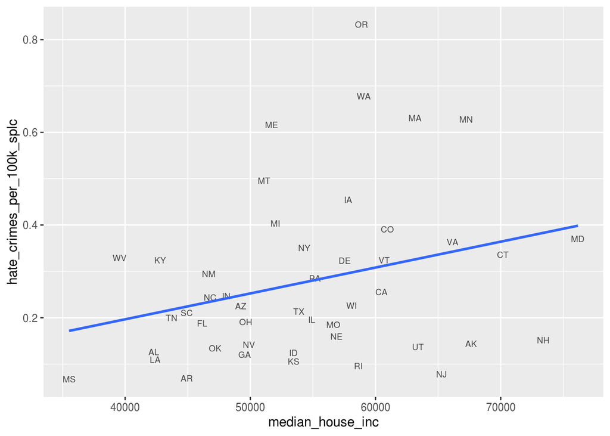

*This graph above shows the relationship between the median household income in 2016 and the hate crimes reports from SPLC. There seems to be a positive correlation between the median household income and the hate crimes reported. The higher median household income in the state, the more hate crimes reported.*

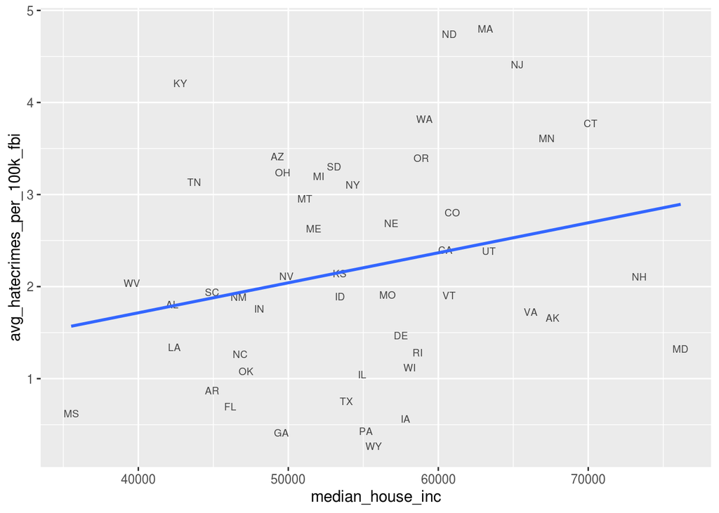

*The graph above shows similar relationship between the median household income and the average hate crimes reported to the FBI. Although there is still a positive correlation between the median income and the average hate crimes, we do see that the average hate crimes reported for many states are not consistent with the level of hate crimes reported by the SPLC.*

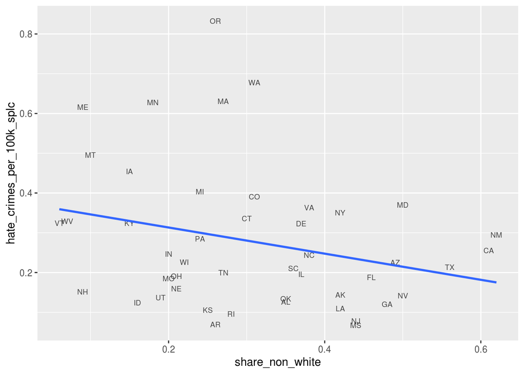

*The graph above shows the relationship between the share of state population that is not white and the hate crimes reported to the SPLC. This shows a negative correlation meaning the more non-white population there is in the state, the lower hate crimes reported.*

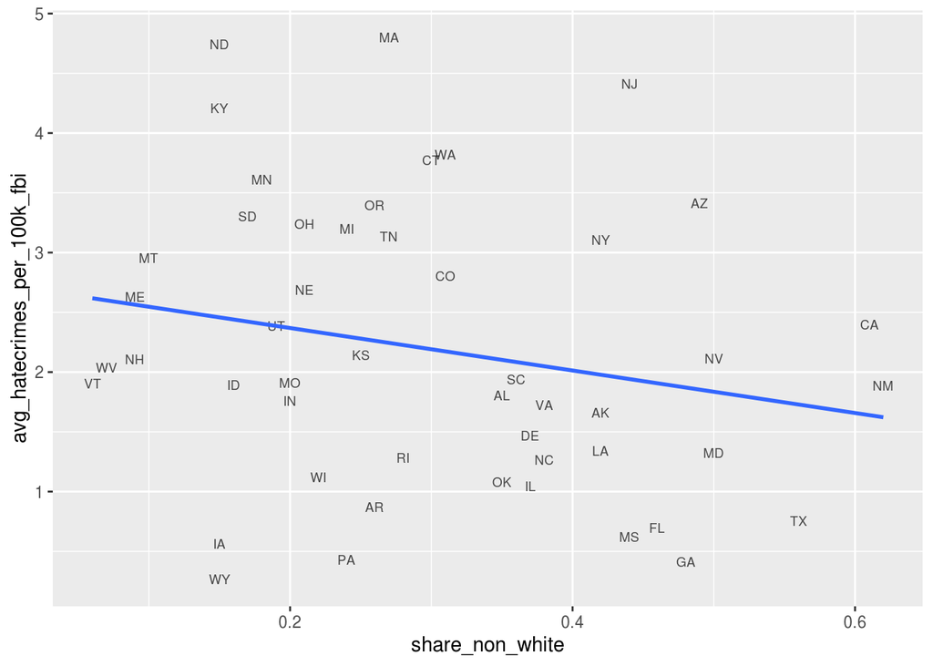

*The graph above shows similar relationship from the previous graph, showing the relationship between the share of the state population that are not white and the average hate crimes reported to the FBI. The result is fairly consistent with the data from the SPLC and it shows that the more non-white population in the state correlate with the lower average hate crimes reported.*

## Fiited Models

| term | estimate | std.error | statistic | p.value |
| --- | --- | --- | --- | --- |
| (Intercept) | 4.119945e-01 | 1.054055e+00 | 0.3908663 | 0.6976623 |
| median_house_inc | 3.258968e-05 | 1.904853e-05 | 1.7108759 | 0.0936976 |

- Firstly, we made a model that explains the correlation between average hate crimes and median household income. The model includes a coefficient that explains how much the rates of hate crimes would possibly increase based on increase in household income.
- Below is the model equation with
  $$\hat{\beta}_0$$
  being the intercept and
  $$\hat{\beta}_I x_I$$
  being the effect income has in increasing instances of hate crime according to this model.

$$\hat{y} = \hat{\beta}_0 + \hat{\beta}_I x_I$$

| term | estimate | std.error | statistic | p.value |
| --- | --- | --- | --- | --- |
| (Intercept) | 1.010559e+00 | 1.126483e+00 | 0.8970917 | 0.3743412 |
| median_house_inc | 3.060064e-05 | 1.890528e-05 | 1.6186293 | 0.1123642 |
| share_non_white | -1.637462e+00 | 1.162862e+00 | -1.4081317 | 0.1658149 |

The second model adds an additional variable, the share of non whites, to the model before, but does not include interaction between household income and share of nonwhite people affecting rates of hate crimes. * median_house_inc explains the predicted increase in hatecrimes along with increase in household income. * share_non_white predicts the decrease in hate crimes based in increasing levels of non white residents in an area. An interesting note is that there is a modeled decrease in hate crimes modeled by increasing the share of non white people.

| term | estimate | std.error | statistic | p.value |
| --- | --- | --- | --- | --- |
| (Intercept) | 2.488708e+00 | 2.473367e+00 | 1.00620230 | 0.3196983 |
| median_house_inc | 3.652682e-06 | 4.436365e-05 | 0.08233501 | 0.9347455 |
| share_non_white | -6.245300e+00 | 6.952434e+00 | -0.89828971 | 0.3738125 |
| median_house_inc:share_non_white | 8.446671e-05 | 1.256286e-04 | 0.67235260 | 0.5047971 |

## Hypothesis testing

| term | estimate | lower_ci | upper_ci |
| --- | --- | --- | --- |
| share_non_white | -1.637 | -3.978 | 0.703 |

Above, we calculated the confidence interval for the predicted effect on rates of hate crimes by the share of non white individuals in an area. * An interesting thing to observe is that there is a decently wide range of possible effect of this coefficient on predicted rates of hate crimes, which is the subject of further investigation later.

| mean_est | sd_est | lower_ci | upper_ci |
| --- | --- | --- | --- |
| -1.55638 | 1.175193 | -3.906765 | 0.7940049 |

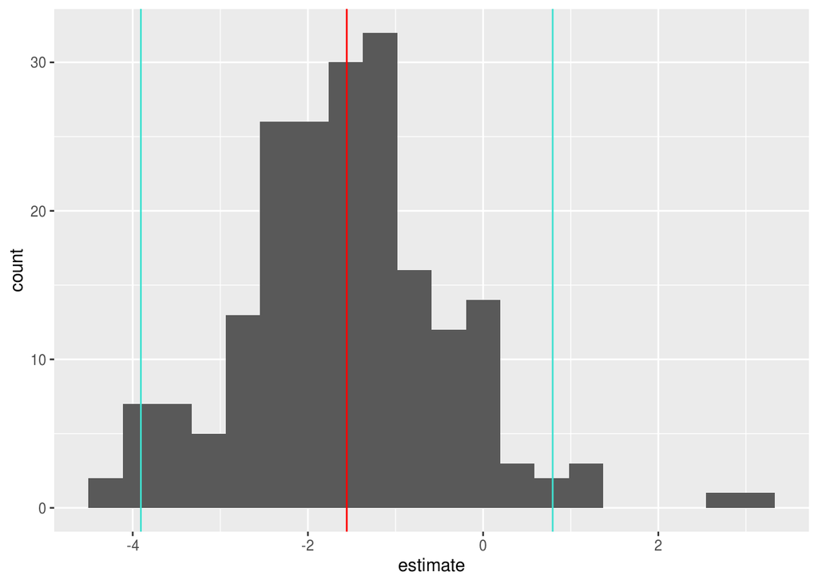

In further study where we might include data on states and voting in the 2016 election, knowing how much the effect that having non white residents in an area can give us more information on where we can pin down the specific effects on data that the different variables may bring.

Further research may be centered on the effect that other factors, mainly state and candidate voted for, have on the number of hate crimes. Having a confidence interval for number of non white people in an area is meant to help facilitate this possible future research. Ultimately, the confidence intervals and p-values are based on how much the data we are presented or we have simulated can vary within the bounds in which we observe and put onto it, and further study could also focus on creating scenarios that may be outside the bounds of our current exploration.

## Limitations

1. The median household income data was the 2016 data and was used to predict the hate crimes data from the FBI that was between 2010-2015 only.
2. Similary, the share of population that is not white was collected in 2015 and was used to explain the hate crime data from the SPLC from 2016 and the FBI data that was an average hate crimes for the 5 years (2010-2015).
3. The p-value suggests that there might not be a correlation between the 2 chosen explainatory variables and the hate-crime rate. Future investigation could be looking at a range of other variables and their interactive effect(s) on the hate crime rate.